# Case Study

Anishka Peter

2023-08-01

# Introduction

Hello, my name is Anishka Peter. I am looking into a dataset from Frito Lay which includes various variables such as Attrition, Age, Business Travel, and Monthly Salary. Using this data set I will build a model to predict attrition for employee based on various factors. Then I will predict emplopyees monthly income using a linear regression.Finally, I will provide additonal insights on various trends related to employees job role.

# RShiny App

https://anishkapeter.shinyapps.io/FritoLayAnalysis/

# Attrition Prediction

## Variable Selection

After looking at many of the variables in bar plots comparing the attrition for each level of the variable, I found that age, overtime, and monthly salary were very influential on attrition.

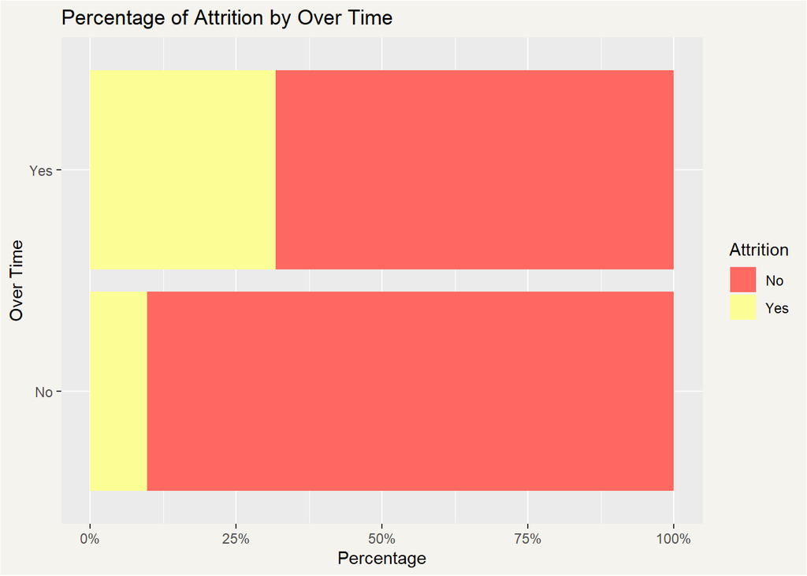

```r
library(ggplot2)
library(aws.s3)
library(dplyr)
library(GGally)
library(RCurl)
data = read.csv("https://raw.githubusercontent.com/anishkapeter/CaseStudy2DDS/main/data_unclean.csv")
data = data[2:37]
## Make Categorical Variables into factors
data$Attrition = as.factor(data$Attrition)
data$Over18 = as.factor(data$Over18)
data$OverTime = as.factor(ifelse(data$OverTime == 'Yes',1,0))
data$BusinessTravel = as.factor(data$BusinessTravel)
data$Department = as.factor(data$Department)
data$EducationField = as.factor(data$EducationField)
data$Education = as.factor(data$Education)
data$EnvironmentSatisfaction = as.factor(data$EnvironmentSatisfaction)
data$Gender = as.factor(data$Gender)
data$JobInvolvement = as.factor(data$JobInvolvement)
data$JobLevel = as.factor(data$JobLevel)
data$JobRole = as.factor(data$JobRole)
data$JobSatisfaction = as.factor(data$JobSatisfaction)
data$MaritalStatus = as.factor(data$MaritalStatus)
data$NumCompaniesWorked = as.factor(data$NumCompaniesWorked)
data$PerformanceRating = as.factor(data$PerformanceRating)
data$RelationshipSatisfaction = as.factor(data$RelationshipSatisfaction)
data$StandardHours = as.factor(data$StandardHours)
data$StockOptionLevel = as.factor(data$StockOptionLevel)
data$WorkLifeBalance = as.factor(data$WorkLifeBalance)

# Seeing What Variables Affect Attrition
#ggplot(data = data, aes(fill = Attrition, x = BusinessTravel)) + geom_bar(position = "dodge")
#ggplot(data = data, aes(fill = Attrition, x = Department)) + geom_bar(position = "dodge")
#ggplot(data = data, aes(fill = Attrition, x = DistanceFromHome)) + geom_bar()
#ggplot(data = data, aes(fill = Attrition, x = EducationField)) + geom_bar(position = "dodge")
#ggplot(data = data, aes(fill = Attrition, x = EnvironmentSatisfaction)) + geom_bar(position = "dodge")
#ggplot(data = data, aes(fill = Attrition, x = JobInvolvement)) + geom_bar(position = "dodge")
#ggplot(data = data, aes(fill = Attrition, x = HourlyRate)) + geom_histogram(position = "dodge")
#ggplot(data = data, aes(fill = Attrition, x = MonthlyRate)) + geom_histogram(position = "dodge")
#ggplot(data = data, aes(fill = Attrition, y = MonthlyIncome, x = MonthlyRate)) + geom_point()
#ggplot(data = data, aes(fill = Attrition, x = PercentSalaryHike)) + geom_bar(position = "dodge")
# Could be By working Years
#ggplot(data = data, aes(fill = Attrition, x = TotalWorkingYears)) + geom_bar(position = "dodge")
#ggplot(data = data, aes(fill = Attrition, x = WorkLifeBalance)) + geom_bar(position = "dodge")
#ggplot(data = data, aes(fill = Attrition, x = YearsAtCompany)) + geom_bar(position = "dodge")
#ggplot(data = data, aes(fill = Attrition, x = YearsInCurrentRole)) + geom_bar(position = "dodge")
#ggplot(data = data, aes(fill = Attrition, x = YearsSinceLastPromotion)) + geom_bar(position = "dodge")


# Seems like it is influential on Attrition
#ggplot(data = data, aes(fill = Attrition, x = JobSatisfaction)) + geom_bar(position = "dodge")


# The total Overtime of Yes is lower than No but Attrition is Higher
colors = c("#FF6961","#FDFD96")
ggplot(data, aes(fill=Attrition, y = OverTime)) +
  geom_bar(position = "fill") +
  scale_x_continuous(labels = scales::percent) +
  ggtitle("Percentage of Attrition by Over Time") +
  xlab("Percentage") +
  ylab("Over Time")+
  scale_fill_manual(values = colors) +
   theme(plot.background = element_rect("#f5f3ed"),
        legend.background = element_blank()) +
  scale_y_discrete(labels=c("No","Yes"))
```

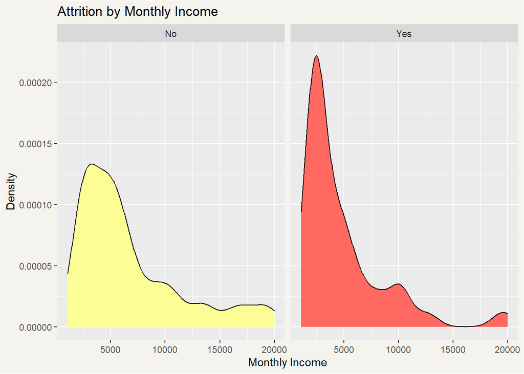

```r
colors = c("#FDFD96","#FF6961")
# Monthly Income Seems influential on Attrition
ggplot(data = data, aes(fill = Attrition, x = MonthlyIncome)) +
  geom_density() +
  facet_wrap(~Attrition) +
  ggtitle("Attrition by Monthly Income") +
  xlab("Monthly Income") +
  ylab("Density") +
  scale_fill_manual(values = colors) +
  theme(plot.background = element_rect("#f5f3ed"), legend.position = "none")
```

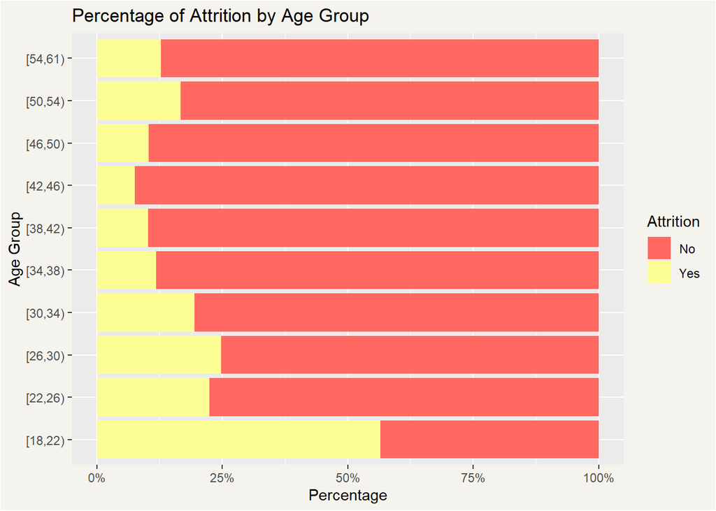

```r
# Make age into categorical
data$Age_Bin <- cut(data$Age, breaks=c(18, 22, 26, 30, 34, 38, 42, 46, 50, 54, 61), right = FALSE)

colors = c("#FF6961","#FDFD96")
ggplot(data, aes(fill=Attrition, y = Age_Bin)) +
  geom_bar(position = "fill") +
  scale_x_continuous(labels = scales::percent) +
  ggtitle("Percentage of Attrition by Age Group") +
  xlab("Percentage") +
  ylab("Age Group")+
  scale_fill_manual(values = colors) +
   theme(plot.background = element_rect("#f5f3ed"),
        legend.background = element_blank())
```

## KNN Model

```r
library(class)
library(caret)
library(e1071)
library(dplyr)
library(tidyverse)
## Checking to see if we can find specificity and sensitivity >60% without doing anything to the data
data$OverTime = as.numeric(data$OverTime)
data$Age_Bin = as.numeric(data$Age_Bin)
trainingindex = sample(1:dim(data)[1],round(.7*dim(data)[1]))
train = data[trainingindex,]
test = data[-trainingindex,]
a = knn(train[,c(20, 24,37)],test[,c(20, 24,37)],train[,3],prob=FALSE, k = 2)
confusionMatrix(a,as.factor(test$Attrition))
```

```
## Confusion Matrix and Statistics
##
##           Reference
## Prediction  No Yes
##        No  185  37
##        Yes  33   6
##
##                Accuracy : 0.7318
##                  95% CI : (0.6737, 0.7846)
##     No Information Rate : 0.8352
##     P-Value [Acc > NIR] : 1.0000
##
##                   Kappa : -0.0123
##
##  Mcnemar's Test P-Value : 0.7199
##
##             Sensitivity : 0.8486
##             Specificity : 0.1395
##          Pos Pred Value : 0.8333
##          Neg Pred Value : 0.1538
##              Prevalence : 0.8352
##          Detection Rate : 0.7088
##    Detection Prevalence : 0.8506
##       Balanced Accuracy : 0.4941
##
##        'Positive' Class : No
##
```

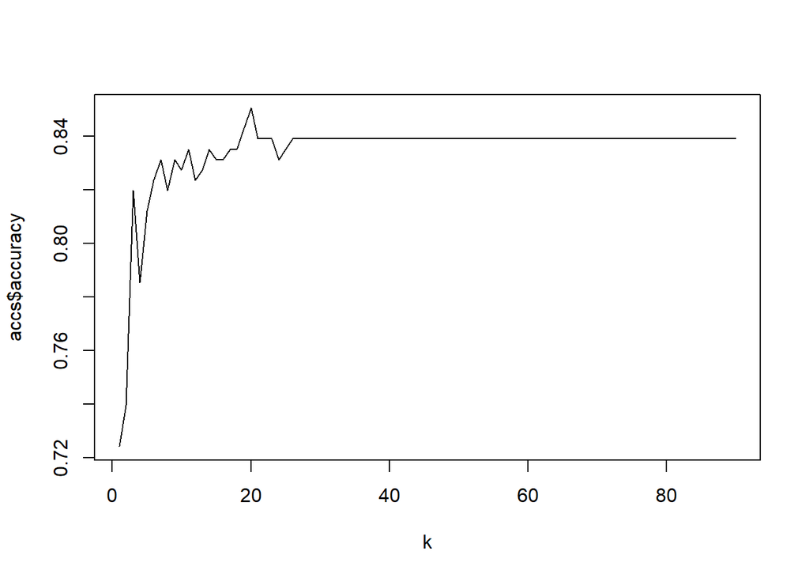

```r
index = sample(1:dim(data)[1],0.7*dim(data[1]))
itrain = data[index,]
itest = data[-index,]

accs = data.frame(accuracy = numeric(90), sensitivity = numeric(90), specificity = numeric(90), k = numeric(90))

for(i in 1:90){
  classifications = knn(itrain[,c(20, 24,37)],itest[,c(20, 24,37)],itrain$Attrition, prob = TRUE, k = i)
  table(itest$Attrition,classifications)
  CM = confusionMatrix(table(itest$Attrition,classifications))
  accs$accuracy[i] = CM$overall[1]
  accs$k[i] = i
  accs$sensitivity[i] = CM$byClass[1]
  accs$specificity[i] = CM$byClass[2]

}

plot(accs$k,accs$accuracy, type = "l", xlab = "k")
```

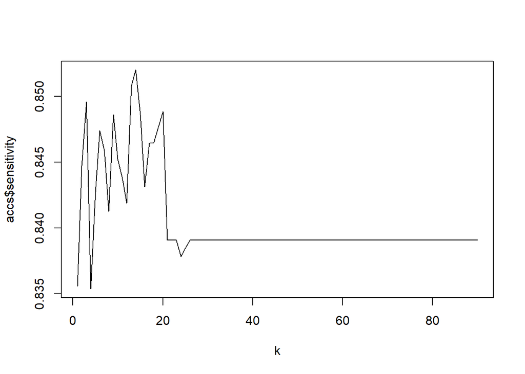

```r
plot(accs$k,accs$sensitivity, type = "l", xlab = "k")
```

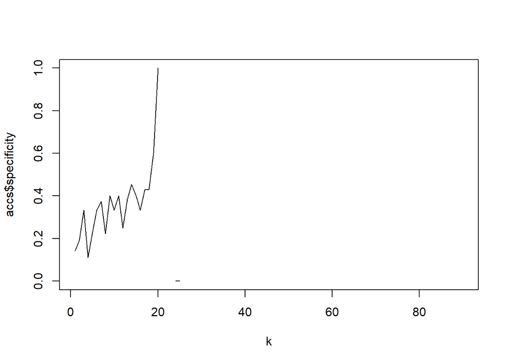

```r
plot(accs$k,accs$specificity, type = "l", xlab = "k")
```

```r
# Can not get a specificity or sensitivity score > 60% on this data
```

```r
## Oversampling
summary(data$Attrition)
```

```
##  No Yes
## 730 140
```

```r
OnlyY = data %>% filter(Attrition == "Yes")
OnlyYOver = rbind(OnlyY,OnlyY[sample(seq(1,140,1),(730-140),replace = TRUE),])
dim(OnlyYOver)
```

```
## [1] 730  37
```

```r
OverSamp = rbind(data %>% filter(Attrition == "No"), OnlyYOver)
dim(OverSamp)
```

```
## [1] 1460   37
```

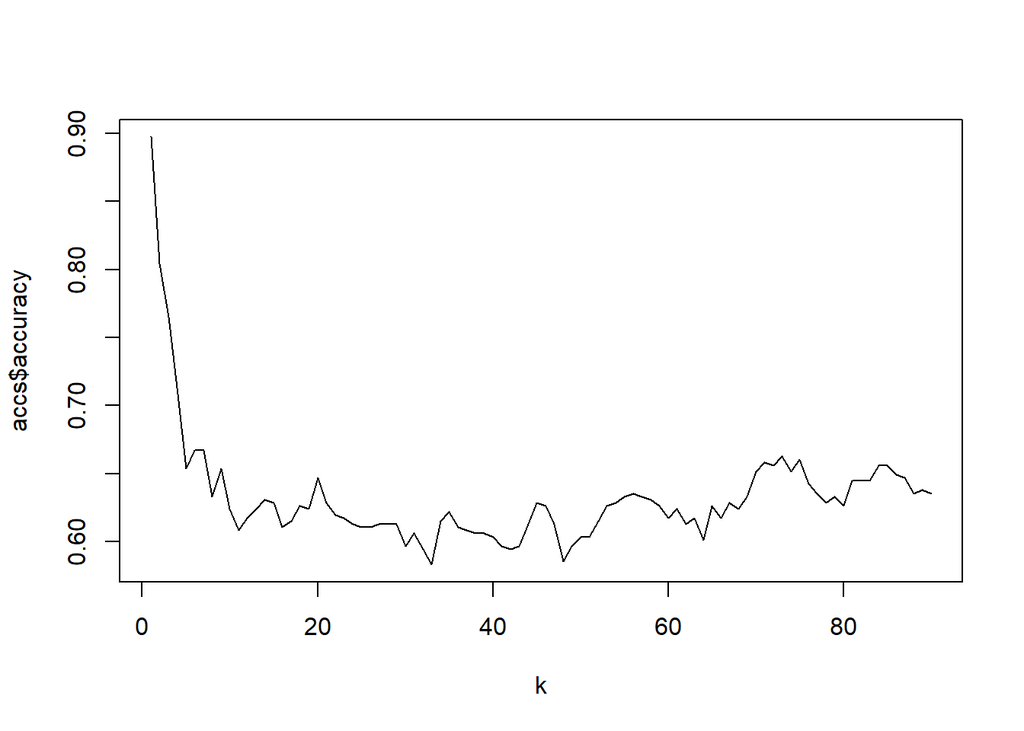

```r
trainIndices = sample(1:dim(OverSamp)[1], 0.7 * dim(OverSamp)[1])
train = OverSamp[trainIndices,]
test = OverSamp[-trainIndices,]


# Finding K with highest Accuracy, sensitivity and specificity
accs = data.frame(accuracy = numeric(90), sensitivity = numeric(90), specificity = numeric(90), k = numeric(90))
for(i in 1:90){
  classifications = knn(train[,c(20, 24,37)],test[,c(20, 24,37)],train$Attrition,
                        prob = TRUE, k = i)
  table(test$Attrition,classifications)
  CM = confusionMatrix(table(test$Attrition,classifications))
  accs$accuracy[i] = CM$overall[1]
  accs$k[i] = i
  accs$sensitivity[i] = CM$byClass[1]
  accs$specificity[i] = CM$byClass[2]

}

plot(accs$k,accs$accuracy, type = "l", xlab = "k")
```

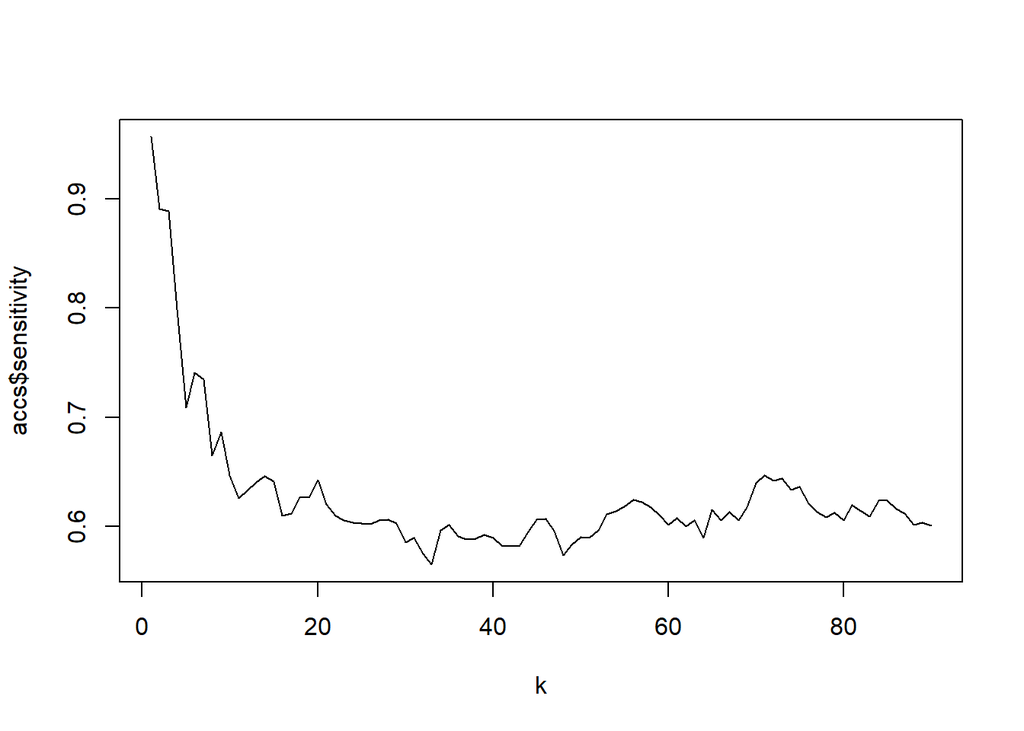

```r
plot(accs$k,accs$sensitivity, type = "l", xlab = "k")
```

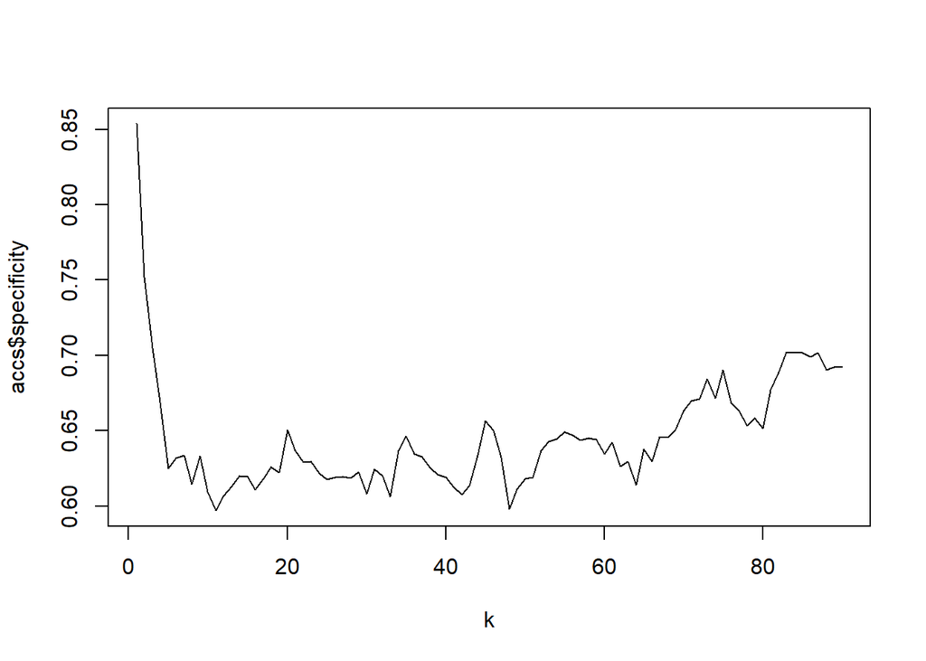

```r
plot(accs$k,accs$specificity, type = "l", xlab = "k")
```

```r
# Seems like 2 has the highest accuracy, specificity, and sensitivity
classifications = knn(train[,c(20, 24,37)],test[,c(20, 24,37)],train[,3], prob = TRUE, k = 2)


CM = confusionMatrix(table(classifications,test[,3]))
CM
```

```
## Confusion Matrix and Statistics
##
##
## classifications  No Yes
##             No  146  13
##             Yes  69 211
##
##                Accuracy : 0.8132
##                  95% CI : (0.7735, 0.8486)
##     No Information Rate : 0.5103
##     P-Value [Acc > NIR] : < 2.2e-16
##
##                   Kappa : 0.6243
##
##  Mcnemar's Test P-Value : 1.25e-09
##
##             Sensitivity : 0.6791
##             Specificity : 0.9420
##          Pos Pred Value : 0.9182
##          Neg Pred Value : 0.7536
##              Prevalence : 0.4897
##          Detection Rate : 0.3326
##    Detection Prevalence : 0.3622
##       Balanced Accuracy : 0.8105
##
##        'Positive' Class : No
##
```

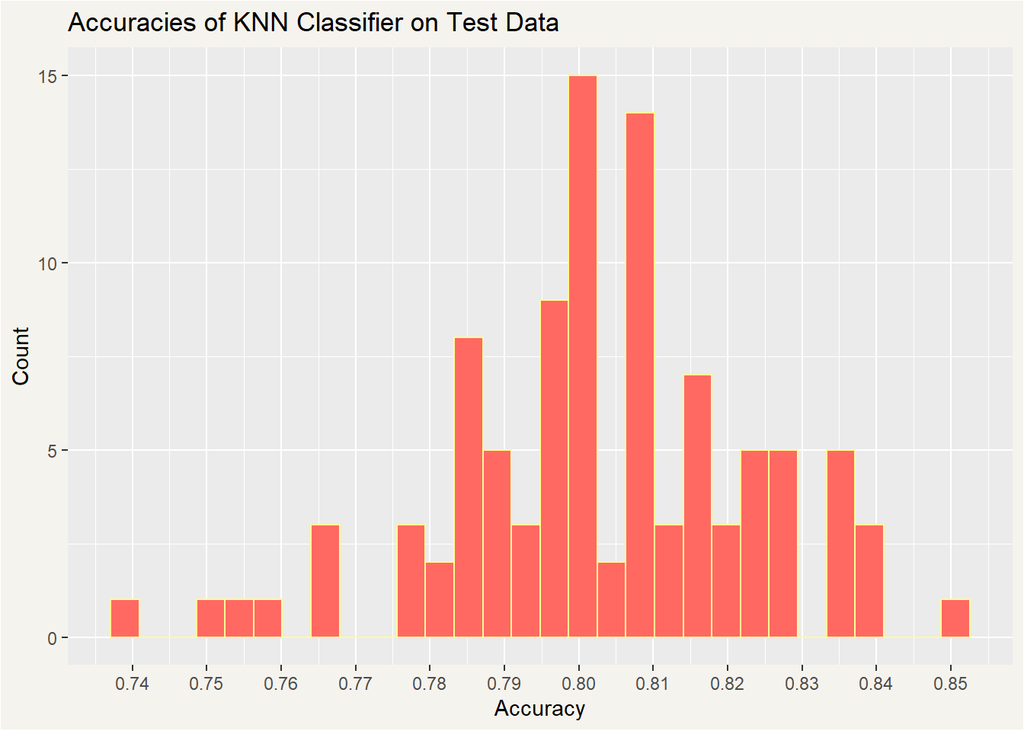

```r
num_seeds <- 100
accuracies <- numeric(num_seeds)
sensitivies <- numeric(num_seeds)
specificities <- numeric(num_seeds)

for (seed in 1:100){
  set.seed(seed)
  trainIndices = sample(1:dim(OverSamp)[1], 0.7 * dim(OverSamp)[1])
  train = OverSamp[trainIndices,]
  test = OverSamp[-trainIndices,]
  classifications = knn(train[,c(24, 37,20)],test[,c(24, 37,20)],train$Attrition, prob = TRUE, k = 2)
  CM = confusionMatrix(table(test$Attrition,classifications))
  accuracies[seed] = CM$overall[1]
  sensitivies[seed] = CM$byClass[1]
  specificities[seed] = CM$byClass[2]
}

# Accuracy histogram for all the Test Train Splits
ggplot(data.frame(accuracies), aes(x = accuracies)) +
  geom_histogram(fill = "#FF6961", color="#FDFD96") +
  xlab("Accuracy") +
  ylab("Count")+
  ggtitle("Accuracies of KNN Classifier on Test Data") +
  theme(plot.background = element_rect("#f5f3ed"))+
  scale_x_continuous(breaks = scales::pretty_breaks(n = 10))
```

```r
min(accuracies) # 74.7%, really good minimum accuracy
```

```
## [1] 0.7403189
```

```r
max(accuracies) # 86.1%
```

```
## [1] 0.8519362
```

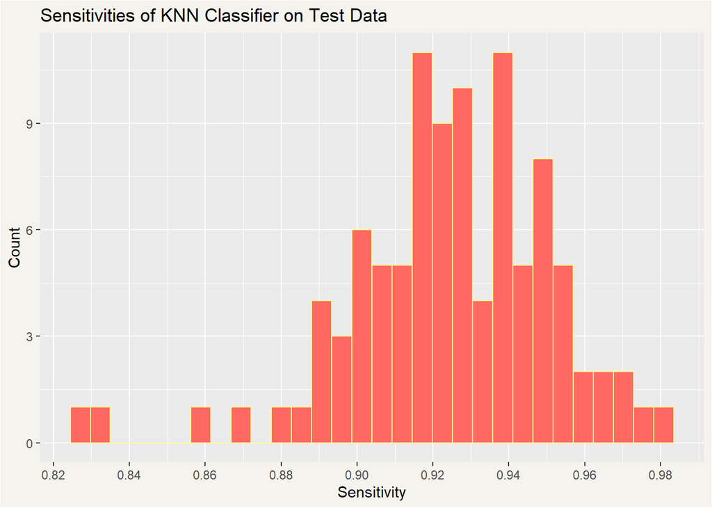

```r
# Sensitivies histogram for all the Test Train Splits
ggplot(data.frame(sensitivies), aes(x = sensitivies)) +
  geom_histogram(fill = "#FF6961", color="#FDFD96") +
  xlab("Sensitivity") +
  ylab("Count")+
  ggtitle("Sensitivities of KNN Classifier on Test Data") +
  theme(plot.background = element_rect("#f5f3ed"))+
  scale_x_continuous(breaks = scales::pretty_breaks(n = 10))
```

```r
min(sensitivies) # 86.4%, really good minimum sensitivity
```

```
## [1] 0.827381
```

```r
max(sensitivies) # 99.3%
```

```
## [1] 0.9811321
```

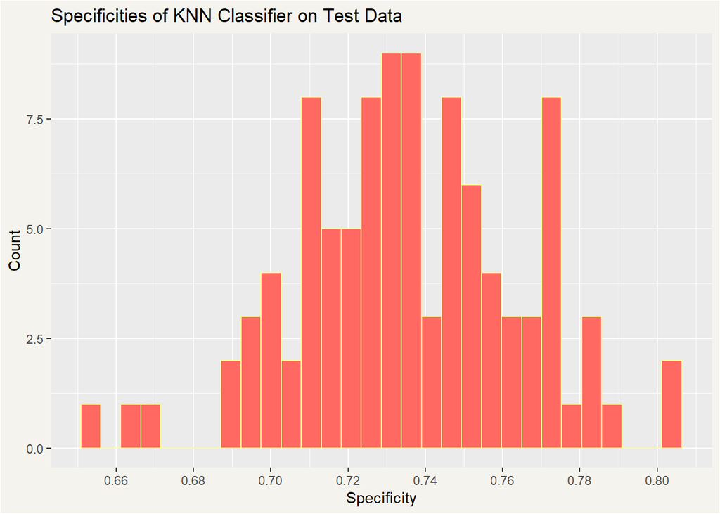

```r
# Specificities histogram for all the Test Train Splits
ggplot(data.frame(specificities), aes(x = specificities)) +
  geom_histogram(fill = "#FF6961", color="#FDFD96") +
  xlab("Specificity") +
  ylab("Count")+
  ggtitle("Specificities of KNN Classifier on Test Data") +
  theme(plot.background = element_rect("#f5f3ed"))+
  scale_x_continuous(breaks = scales::pretty_breaks(n = 10))
```

```r
min(specificities) # 65.17%
```

```
## [1] 0.6530612
```

```r
max(specificities) # 80.8%
```

```
## [1] 0.8034483
```

```r
mean(accuracies)
```

```
## [1] 0.8029385
```

```r
mean(sensitivies)
```

```
## [1] 0.9245457
```

```r
mean(specificities)
```

```
## [1] 0.7358943
```

## Naive Bayes Model

```r
# Build a NB model on original data
trainIndices = sample(seq(1:length(data$Attrition)),round(.7*length(data$Attrition)))
train = data[trainIndices,]
test = data[-trainIndices,]
model = naiveBayes(train[,c(24,37,20)], train$Attrition)
a = table(factor(test$Attrition),predict(model,test[,c(24,37,20)]))
confusionMatrix(a) # not a good specificity Score
```

```
## Confusion Matrix and Statistics
##
##
##        No Yes
##   No  216   5
##   Yes  34   6
##
##                Accuracy : 0.8506
##                  95% CI : (0.8014, 0.8915)
##     No Information Rate : 0.9579
##     P-Value [Acc > NIR] : 1
##
##                   Kappa : 0.1812
##
##  Mcnemar's Test P-Value : 7.34e-06
##
##             Sensitivity : 0.8640
##             Specificity : 0.5455
##          Pos Pred Value : 0.9774
##          Neg Pred Value : 0.1500
##              Prevalence : 0.9579
##          Detection Rate : 0.8276
##    Detection Prevalence : 0.8467
##       Balanced Accuracy : 0.7047
##
##        'Positive' Class : No
##
```

```r
# Build NB model on oversampled data
OnlyY = data %>% filter(Attrition == "Yes")
OnlyYOver = rbind(OnlyY,OnlyY[sample(seq(1,140,1),(730-140),replace = TRUE),])
dim(OnlyYOver)
```

```
## [1] 730  37
```

```r
OverSamp = rbind(data %>% filter(Attrition == "No"), OnlyYOver)
dim(OverSamp)
```

```
## [1] 1460   37
```

```r
trainIndices = sample(1:dim(OverSamp)[1], 0.7 * dim(OverSamp)[1])
train = OverSamp[trainIndices,]
test = OverSamp[-trainIndices,]
model = naiveBayes(train[,c(24,37,20)], train$Attrition)
a = table(factor(test$Attrition),predict(model,test[,c(24,37,20)]))
confusionMatrix(a) # Better Model than the original data
```

```
## Confusion Matrix and Statistics
##
##
##        No Yes
##   No  142  55
##   Yes 111 131
##
##                Accuracy : 0.6219
##                  95% CI : (0.5747, 0.6674)
##     No Information Rate : 0.5763
##     P-Value [Acc > NIR] : 0.02933
##
##                   Kappa : 0.2554
##
##  Mcnemar's Test P-Value : 1.965e-05
##
##             Sensitivity : 0.5613
##             Specificity : 0.7043
##          Pos Pred Value : 0.7208
##          Neg Pred Value : 0.5413
##              Prevalence : 0.5763
##          Detection Rate : 0.3235
##    Detection Prevalence : 0.4487
##       Balanced Accuracy : 0.6328
##
##        'Positive' Class : No
##
```

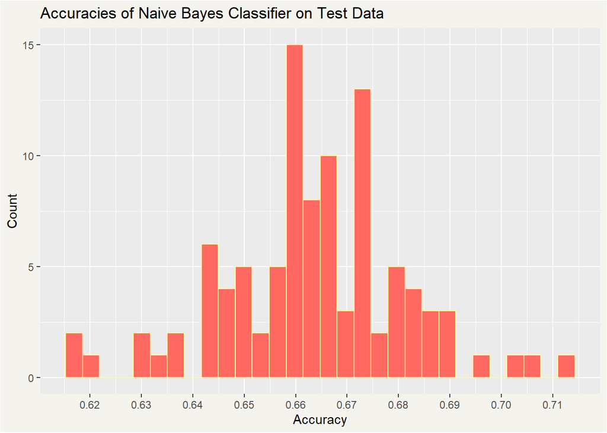

```r
# Testing to see the different Sensitivity and Specificity for various Seeds
for (seed in 1:100){
  set.seed(seed)
  trainIndices = sample(1:dim(OverSamp)[1], 0.7 * dim(OverSamp)[1])
  train = OverSamp[trainIndices,]
  test = OverSamp[-trainIndices,]
  model = naiveBayes(train[,c(24,37,20)], train$Attrition)
  a = table(factor(test$Attrition),predict(model,test[,c(24,37,20)]))
  CM = confusionMatrix(a)
  accuracies[seed] = CM$overall[1]
  sensitivies[seed] = CM$byClass[1]
  specificities[seed] = CM$byClass[2]
}

# Accuracy histogram for all the Test Train Splits
ggplot(data.frame(accuracies), aes(x = accuracies)) +
  geom_histogram(fill = "#FF6961", color = "#FDFD96") +
  xlab("Accuracy") +
  ylab("Count")+
  ggtitle("Accuracies of Naive Bayes Classifier on Test Data") +
  theme(plot.background = element_rect("#f5f3ed"))+
  scale_x_continuous(breaks = scales::pretty_breaks(n = 10))
```

```r
min(accuracies) # 63.6%, really good minimum accuracy
```

```
## [1] 0.6173121
```

```r
max(accuracies) # 72%
```

```
## [1] 0.7129841
```

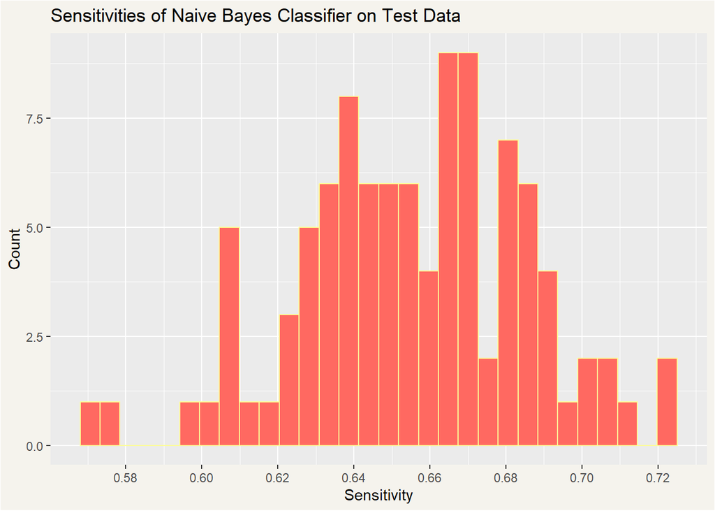

```r
# Sensitivies histogram for all the Test Train Splits
ggplot(data.frame(sensitivies), aes(x = sensitivies)) +
  geom_histogram(fill = "#FF6961", color = "#FDFD96") +
  xlab("Sensitivity") +
  ylab("Count")+
  ggtitle("Sensitivities of Naive Bayes Classifier on Test Data") +
  theme(plot.background = element_rect("#f5f3ed"))+
  scale_x_continuous(breaks = scales::pretty_breaks(n = 10))
```

```r
min(sensitivies) # 60.7%, really good minimum sensitivity
```

```
## [1] 0.5730769
```

```r
max(sensitivies) # 74.1%
```

```
## [1] 0.7248908
```

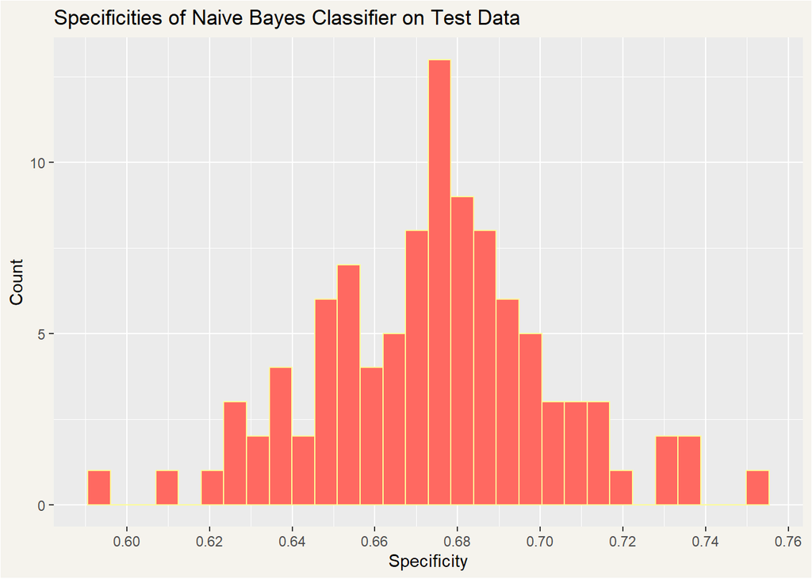

```r
# Specificities histogram for all the Test Train Splits
ggplot(data.frame(specificities), aes(x = specificities)) +
  geom_histogram(fill = "#FF6961", color = "#FDFD96") +
  xlab("Specificity") +
  ylab("Count")+
  ggtitle("Specificities of Naive Bayes Classifier on Test Data") +
  theme(plot.background = element_rect("#f5f3ed"))+
  scale_x_continuous(breaks = scales::pretty_breaks(n = 10))
```

```r
min(specificities) # 60.5%
```

```
## [1] 0.5906977
```

```r
max(specificities) # 74.4%
```

```
## [1] 0.75
```

## Prediction using KNN

Based on the sensitvity and specificity scores, the KNN model created from oversampling seems to be better at identify attrition, so I will use it to predict the attrition of the competition dataset.

```r
# Load in Competition Dataset
competition = read.table(textConnection(getURL(
  "https://s3.us-east-2.amazonaws.com/ddsproject1/CaseStudy2CompSet%20No%20Attrition.csv"
)), sep=",", header=TRUE)


# Clean the Data to be used in model
competition$Age_Bin <- cut(competition$Age, breaks=c(18, 22, 26, 30, 34, 38, 42, 46, 50, 54, 61), right = FALSE)
competition$OverTime = as.factor(ifelse(competition$OverTime == 'Yes',1,0))
competition$OverTime = as.numeric(competition$OverTime)
competition$Age_Bin = as.numeric(competition$Age_Bin)

# Oversample the training data
OnlyY = data %>% filter(Attrition == "Yes")
OnlyYOver = rbind(OnlyY,OnlyY[sample(seq(1,140,1),(730-140),replace = TRUE),])
dim(OnlyYOver)
```

```
## [1] 730  37
```

```r
OverSamp = rbind(data %>% filter(Attrition == "No"), OnlyYOver)
dim(OverSamp)
```

```
## [1] 1460   37
```

```r
Attritionclass = knn(OverSamp[,c(20, 24,37)],competition[,c(19, 23,36)],OverSamp[,3], prob = TRUE, k = 2)

Case2PredictionsPeterAttrition = data.frame(competition,Attritionclass)
Case2PredictionsPeterAttrition = Case2PredictionsPeterAttrition[,c(1,37)]
write.csv(Case2PredictionsPeterAttrition,"C:/DoingDataScience/CaseStudy2DDS/Case2PredictionsPeterAttrition.csv")
```

# Salary Prediction

## Looking at Variable Correlation

After looking at various variables, it seems like Education Field, Department, YearsAtCompany, Education, JobRole, JobLevel, and TotalWorkingYears are potentially influential in predicting the Monthly Income of an Individual.

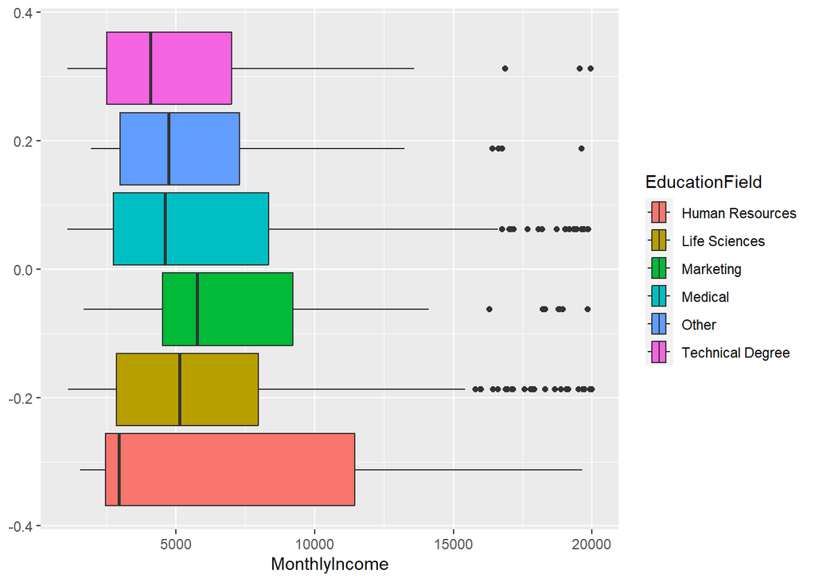

```r
#ggplot(data = data, aes(x = MonthlyIncome, fill = BusinessTravel)) + geom_boxplot() # seems like same income for all type of travel
#ggplot(data = data, aes(x = MonthlyIncome, fill = JobInvolvement)) + geom_boxplot() # seems the same for all involement levels
#ggplot(data = data, aes(y = MonthlyIncome, x = HourlyRate)) + geom_point() # not related

# Not really correlated
#ggplot(data = data, aes(y = MonthlyIncome, x = YearsInCurrentRole)) + geom_point()


ggplot(data = data, aes(x = MonthlyIncome, fill = EducationField)) + geom_boxplot() # income seems different by education field
```

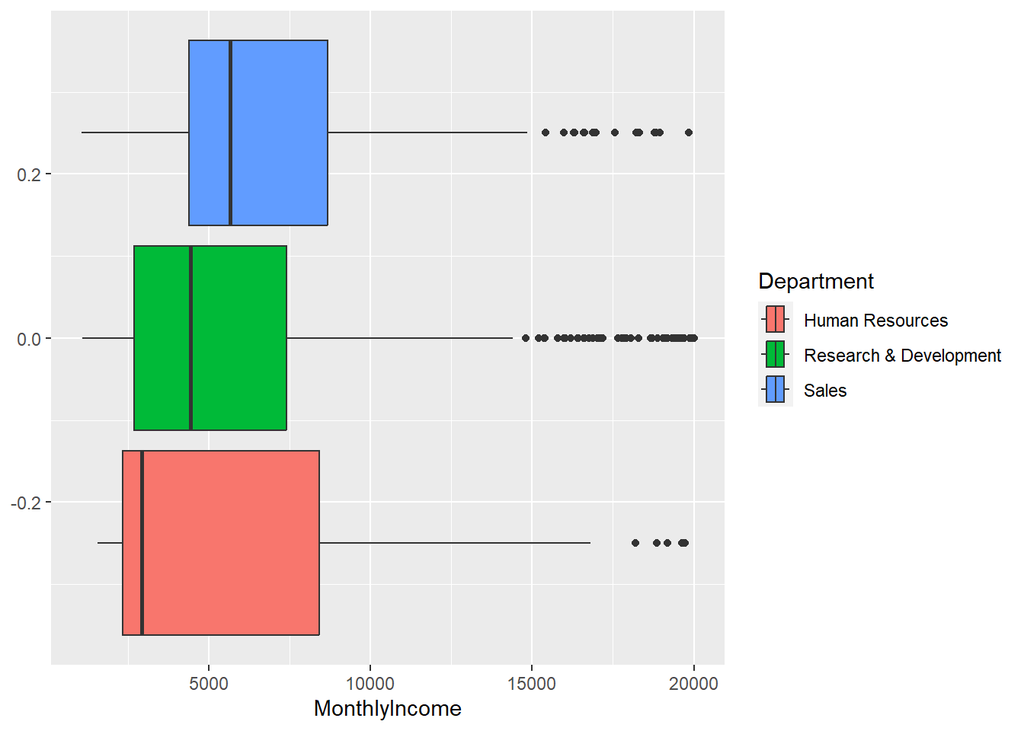

```r
ggplot(data = data, aes(x = MonthlyIncome, fill = Department)) + geom_boxplot() # income seems different by department
```

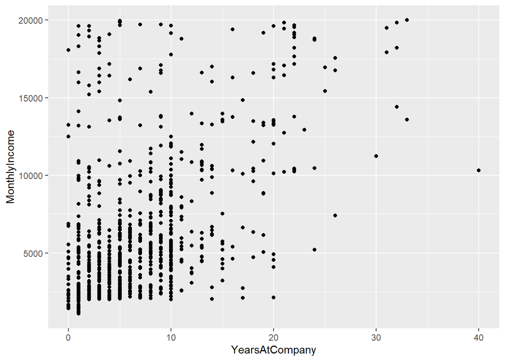

```r
# seems kinda positively correlated
ggplot(data = data, aes(y = MonthlyIncome, x = YearsAtCompany)) + geom_point()
```

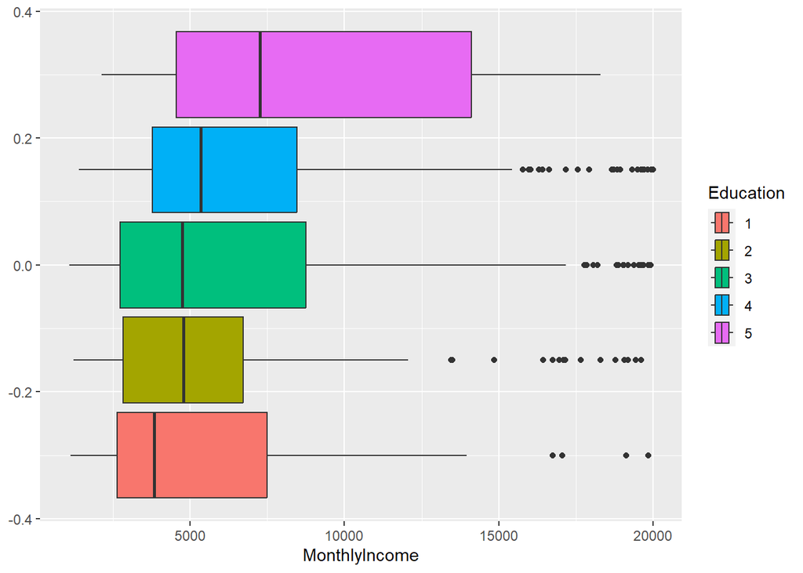

```r
#seems  like different education affect the salary
ggplot(data = data, aes(x = MonthlyIncome, fill = Education)) + geom_boxplot()
```

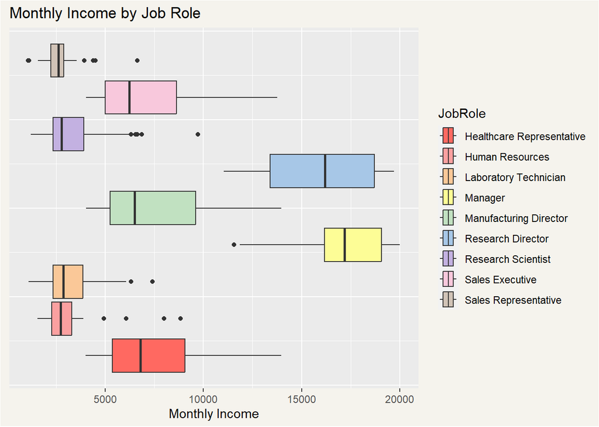

```r
color = c("#FF6961","#FAA0A0", "#FAC898","#FDFD96","#C1E1C1", "#A7C7E7", "#C3B1E1", "#F8C8DC","#D1C3B7")

# Very much different for each role
ggplot(data = data, aes(x = MonthlyIncome, fill = JobRole)) +
  geom_boxplot() +
  ggtitle("Monthly Income by Job Role") +
  xlab("Monthly Income") +
  theme(plot.background = element_rect("#f5f3ed"),
        legend.background = element_blank(),
        axis.ticks.y = element_blank(),
        axis.text.y = element_blank()) +
  scale_fill_manual(values = color)
```

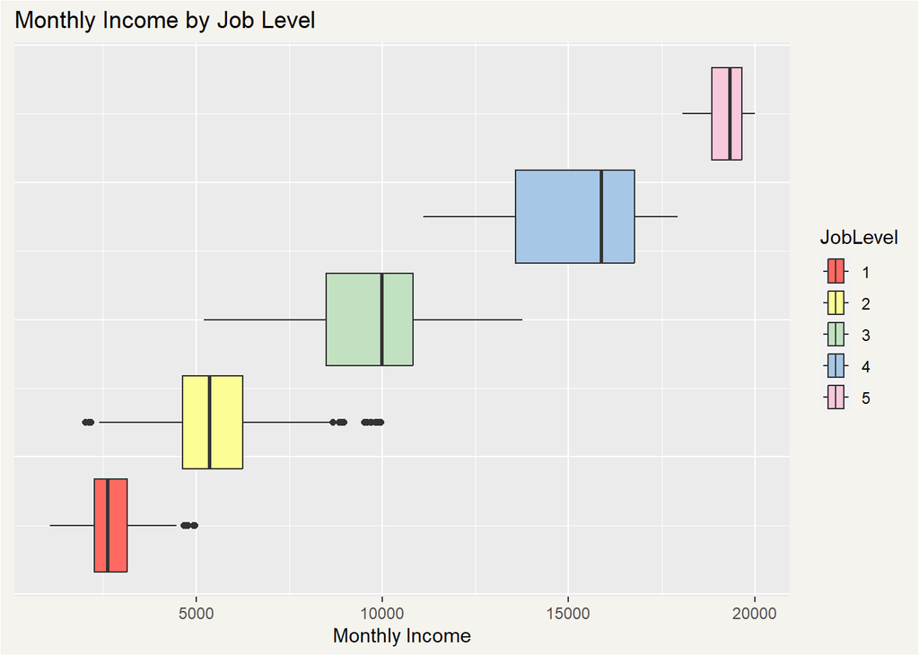

```r
color = c("#FF6961","#FDFD96","#C1E1C1", "#A7C7E7", "#F8C8DC","#D1C3B7")
# Very Different Income for each level
ggplot(data = data, aes(x = MonthlyIncome, fill = JobLevel)) +
  geom_boxplot() +
  ggtitle("Monthly Income by Job Level") +
  xlab("Monthly Income") +
  theme(plot.background = element_rect("#f5f3ed"),
        legend.background = element_blank(),
        axis.ticks.y = element_blank(),
        axis.text.y = element_blank()) +
  scale_fill_manual(values = color)
```

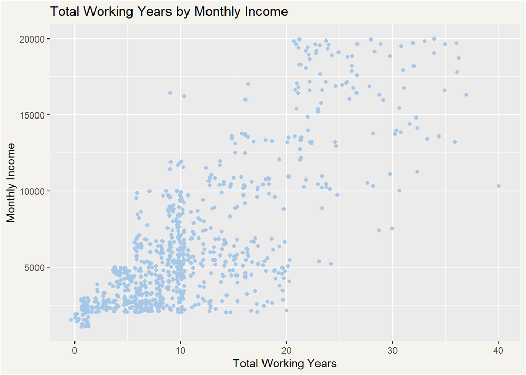

```r
# Positively Correlated
color = c("#FF6961","#FDFD96","#C1E1C1", "#A7C7E7", "#F8C8DC","#D1C3B7")
ggplot(data = data, aes(y = MonthlyIncome, x = TotalWorkingYears)) +
  geom_point(color = "#A7C7E7",position = "jitter") +
  ggtitle("Total Working Years by Monthly Income") +
  xlab("Total Working Years") +
  ylab("Monthly Income") +
  theme(plot.background = element_rect("#f5f3ed"))
```

## Testing the Variables Significance

The p-values of Job Role, Job Level and Total Working Years are significant so I made a model using those 3 variables.

```r
fit = lm(MonthlyIncome ~ EducationField + Department + YearsAtCompany + Education + JobRole + JobLevel + TotalWorkingYears, data = data)
summary(fit)
```

```
##
## Call:
## lm(formula = MonthlyIncome ~ EducationField + Department + YearsAtCompany +
##     Education + JobRole + JobLevel + TotalWorkingYears, data = data)
##
## Residuals:
##     Min      1Q  Median      3Q     Max
## -3169.1  -641.9   -61.1   595.9  4300.5
##
## Coefficients:
##                                   Estimate Std. Error t value Pr(>|t|)
## (Intercept)                       3402.470    501.253   6.788 2.14e-11 ***
## EducationFieldLife Sciences         35.003    348.906   0.100   0.9201
## EducationFieldMarketing            -14.257    369.296  -0.039   0.9692
## EducationFieldMedical              -54.501    349.487  -0.156   0.8761
## EducationFieldOther                -32.860    374.404  -0.088   0.9301
## EducationFieldTechnical Degree     -20.353    363.988  -0.056   0.9554
## DepartmentResearch & Development   260.147    456.204   0.570   0.5687
## DepartmentSales                   -259.866    468.226  -0.555   0.5790
## YearsAtCompany                      -1.946      7.525  -0.259   0.7960
## Education2                         -51.120    128.283  -0.398   0.6904
## Education3                        -101.660    117.876  -0.862   0.3887
## Education4                          52.310    124.680   0.420   0.6749
## Education5                        -435.137    229.348  -1.897   0.0581 .
## JobRoleHuman Resources            -819.657    493.369  -1.661   0.0970 .
## JobRoleLaboratory Technician     -1222.065    176.299  -6.932 8.26e-12 ***
## JobRoleManager                    3564.348    282.354  12.624  < 2e-16 ***
## JobRoleManufacturing Director      134.700    159.048   0.847   0.3973
## JobRoleResearch Director          3509.899    214.757  16.344  < 2e-16 ***
## JobRoleResearch Scientist        -1015.691    179.697  -5.652 2.17e-08 ***
## JobRoleSales Executive             505.780    338.878   1.493   0.1359
## JobRoleSales Representative       -745.644    380.358  -1.960   0.0503 .
## JobLevel2                         1697.580    141.258  12.018  < 2e-16 ***
## JobLevel3                         4944.834    189.977  26.029  < 2e-16 ***
## JobLevel4                         8322.425    286.781  29.020  < 2e-16 ***
## JobLevel5                        11031.278    336.415  32.791  < 2e-16 ***
## TotalWorkingYears                   46.126      8.638   5.340 1.20e-07 ***
## ---
## Signif. codes:  0 '***' 0.001 '**' 0.01 '*' 0.05 '.' 0.1 ' ' 1
##
## Residual standard error: 1008 on 844 degrees of freedom
## Multiple R-squared:  0.9534, Adjusted R-squared:  0.952
## F-statistic:   690 on 25 and 844 DF,  p-value: < 2.2e-16
```

```r
fit = lm(MonthlyIncome ~ JobRole + JobLevel + TotalWorkingYears, data = data)
summary(fit)
```

```
##
## Call:
## lm(formula = MonthlyIncome ~ JobRole + JobLevel + TotalWorkingYears,
##     data = data)
##
## Residuals:
##     Min      1Q  Median      3Q     Max
## -3184.4  -622.9   -83.6   623.4  4282.9
##
## Coefficients:
##                                Estimate Std. Error t value Pr(>|t|)
## (Intercept)                    3620.912    180.824  20.025  < 2e-16 ***
## JobRoleHuman Resources        -1106.211    252.764  -4.376 1.36e-05 ***
## JobRoleLaboratory Technician  -1243.528    175.324  -7.093 2.75e-12 ***
## JobRoleManager                 3332.134    237.808  14.012  < 2e-16 ***
## JobRoleManufacturing Director   134.719    158.506   0.850    0.396
## JobRoleResearch Director       3479.341    211.496  16.451  < 2e-16 ***
## JobRoleResearch Scientist     -1040.524    178.715  -5.822 8.21e-09 ***
## JobRoleSales Executive          -13.146    136.850  -0.096    0.923
## JobRoleSales Representative   -1267.454    220.601  -5.745 1.27e-08 ***
## JobLevel2                      1687.533    139.069  12.134  < 2e-16 ***
## JobLevel3                      4913.569    186.878  26.293  < 2e-16 ***
## JobLevel4                      8246.787    282.379  29.205  < 2e-16 ***
## JobLevel5                     11003.473    332.523  33.091  < 2e-16 ***
## TotalWorkingYears                45.975      7.768   5.918 4.70e-09 ***
## ---
## Signif. codes:  0 '***' 0.001 '**' 0.01 '*' 0.05 '.' 0.1 ' ' 1
##
## Residual standard error: 1007 on 856 degrees of freedom
## Multiple R-squared:  0.9527, Adjusted R-squared:  0.952
## F-statistic:  1327 on 13 and 856 DF,  p-value: < 2.2e-16
```

## Comparing Models

Job Level and Job Role are both factor variables so we will check if interaction variables are better for the model. Based on build your own anova’s we found that adding the job role and job level as interaction variables is significant compared to having them as indicator variables.

```r
fit1 = lm(MonthlyIncome ~ JobRole + JobLevel + TotalWorkingYears, data = data)
anova(fit1)
```

```
## Analysis of Variance Table
##
## Response: MonthlyIncome
##                    Df     Sum Sq    Mean Sq  F value    Pr(>F)
## JobRole             8 1.4888e+10 1861023729 1834.311 < 2.2e-16 ***
## JobLevel            4 2.5774e+09  644358301  635.109 < 2.2e-16 ***
## TotalWorkingYears   1 3.5535e+07   35535456   35.025 4.705e-09 ***
## Residuals         856 8.6847e+08    1014563
## ---
## Signif. codes:  0 '***' 0.001 '**' 0.01 '*' 0.05 '.' 0.1 ' ' 1
```

```r
fit2 = lm(MonthlyIncome ~ JobRole + JobLevel * TotalWorkingYears, data = data)
anova(fit2)
```

```
## Analysis of Variance Table
##
## Response: MonthlyIncome
##                             Df     Sum Sq    Mean Sq  F value    Pr(>F)
## JobRole                      8 1.4888e+10 1861023729 1851.959 < 2.2e-16 ***
## JobLevel                     4 2.5774e+09  644358301  641.220 < 2.2e-16 ***
## TotalWorkingYears            1 3.5535e+07   35535456   35.362 3.991e-09 ***
## JobLevel:TotalWorkingYears   4 1.2296e+07    3073955    3.059   0.01618 *
## Residuals                  852 8.5617e+08    1004894
## ---
## Signif. codes:  0 '***' 0.001 '**' 0.01 '*' 0.05 '.' 0.1 ' ' 1
```

```r
fit3 = lm(MonthlyIncome ~ JobRole * JobLevel * TotalWorkingYears, data = data)
anova(fit3)
```

```
## Analysis of Variance Table
##
## Response: MonthlyIncome
##                                     Df     Sum Sq    Mean Sq   F value
## JobRole                              8 1.4888e+10 1861023729 1911.3593
## JobLevel                             4 2.5774e+09  644358301  661.7864
## TotalWorkingYears                    1 3.5535e+07   35535456   36.4966
## JobRole:JobLevel                    13 3.0960e+07    2381510    2.4459
## JobRole:TotalWorkingYears            8 7.8847e+06     985588    1.0122
## JobLevel:TotalWorkingYears           4 2.4779e+07    6194853    6.3624
## JobRole:JobLevel:TotalWorkingYears  11 6.4368e+06     585164    0.6010
## Residuals                          820 7.9841e+08     973665
##                                       Pr(>F)
## JobRole                            < 2.2e-16 ***
## JobLevel                           < 2.2e-16 ***
## TotalWorkingYears                  2.318e-09 ***
## JobRole:JobLevel                    0.002941 **
## JobRole:TotalWorkingYears           0.424954
## JobLevel:TotalWorkingYears         4.819e-05 ***
## JobRole:JobLevel:TotalWorkingYears  0.828934
## Residuals
## ---
## Signif. codes:  0 '***' 0.001 '**' 0.01 '*' 0.05 '.' 0.1 ' ' 1
```

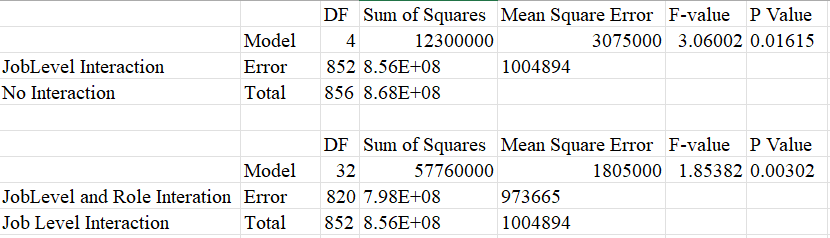

2 Build your own ANOVA to determine statistical significance of models

## Final Model To Predict the Monthly Salary

```r
# Final Model
fit = lm(MonthlyIncome ~ JobRole * JobLevel * TotalWorkingYears, data = data)
predictsalary = predict(fit)



# RMSE
MSE = sum((data$MonthlyIncome-predictsalary)^2)*1/870
RMSE = sqrt(MSE)
RMSE
```

```
## [1] 957.9704
```

```r
# Predicted Salary Values
competitionsalary = read.table(textConnection(getURL(
  "https://s3.us-east-2.amazonaws.com/ddsproject1/CaseStudy2CompSet%20No%20Salary.csv"
)), sep=",", header=TRUE)


competitionsalary$JobLevel = as.factor(competitionsalary$JobLevel)

monthlyincomeprediction = predict(fit, newdata = competitionsalary)
Case2PredictionsPeterSalary = data.frame(competitionsalary[,1], monthlyincomeprediction)
names(Case2PredictionsPeterSalary) = c("ID", "MonthlyIncome")
Case2PredictionsPeterSalary$MonthlyIncome = as.integer(Case2PredictionsPeterSalary$MonthlyIncome)

write.csv(Case2PredictionsPeterSalary, "C:/DoingDataScience/CaseStudy2DDS/Case2PredictionsPeterSalary.csv")
```

# Job Role Trends

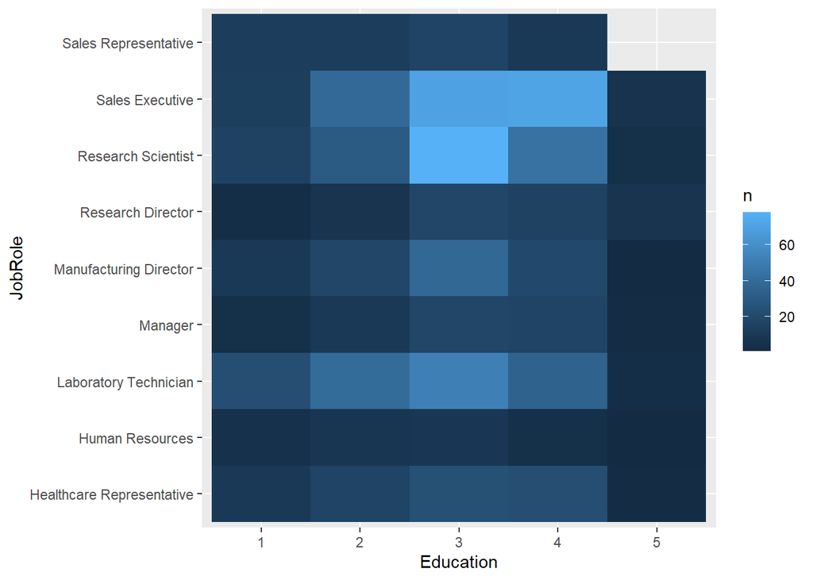

```r
data %>%
count(Education, JobRole) %>%
ggplot(aes(x = Education, y = JobRole)) +
geom_tile(mapping = aes(fill = n))
```

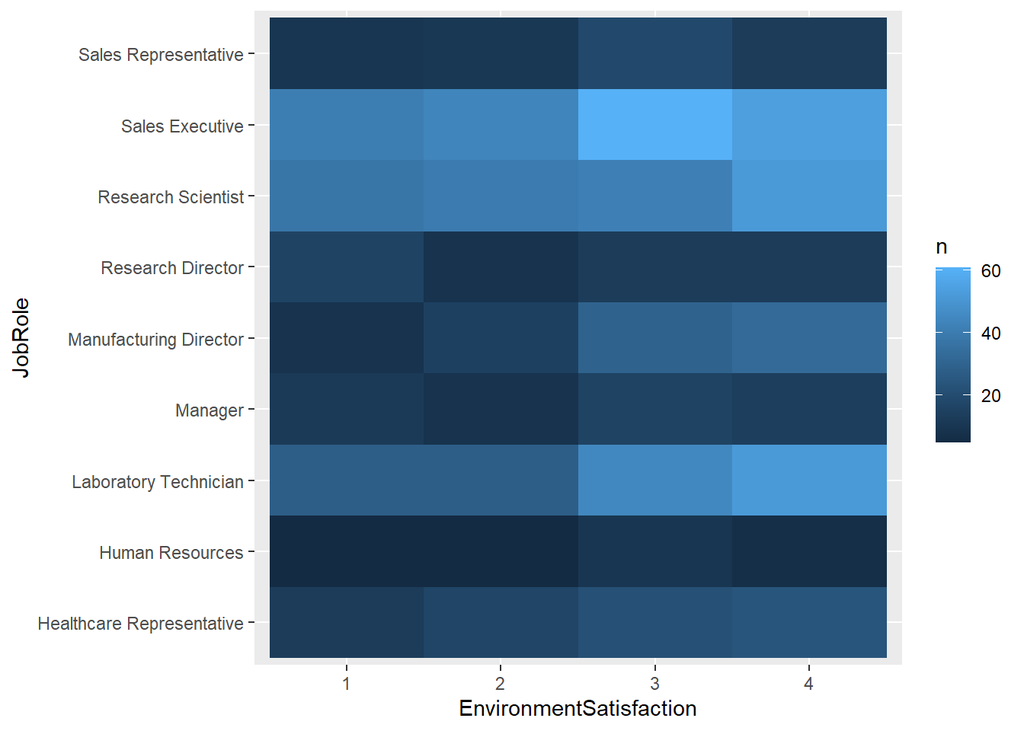

```r
data %>%
count(EnvironmentSatisfaction, JobRole) %>%
ggplot(aes(x = EnvironmentSatisfaction, y = JobRole)) +
geom_tile(mapping = aes(fill = n))
```

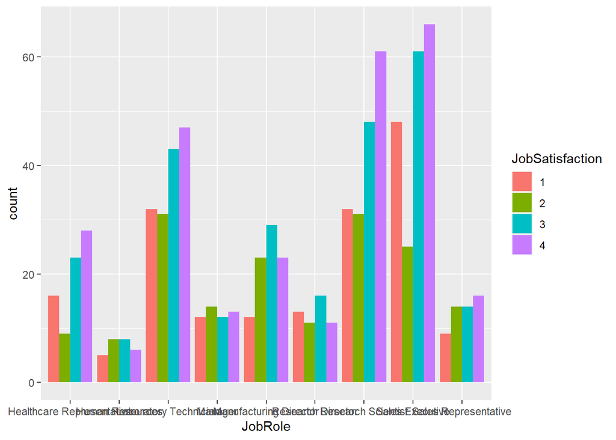

```r
# Job Satisfaction of Each Role
ggplot(data, aes(x=JobRole, fill = JobSatisfaction)) + geom_bar(stat="count",position = "dodge")
```

```r
individualjobrole = data %>%
  count(JobRole,JobSatisfaction)

totaljobrole = data %>%
  group_by(JobRole) %>%
  summarise(total = n())

jobrolessatisfaction = merge(individualjobrole,totaljobrole, by="JobRole")

percentjobrolesatisfaction = jobrolessatisfaction %>%
  summarise(percent = n/total*100)
```

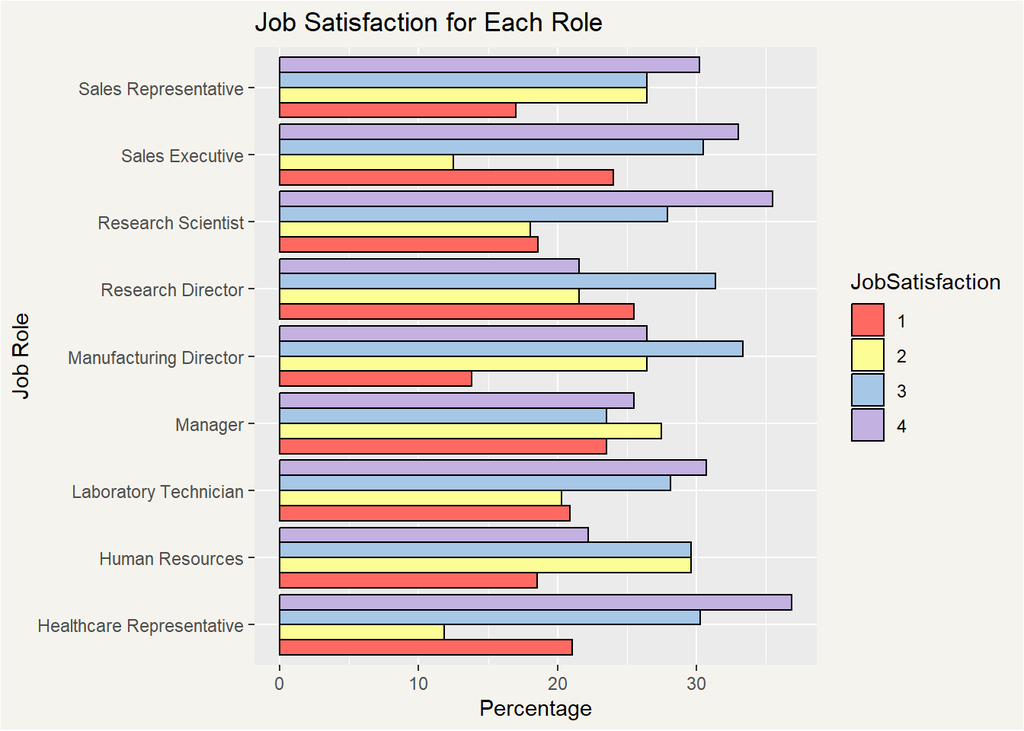

```r
percentagessatisfaction = data.frame(jobrolessatisfaction,percentjobrolesatisfaction)

color = c("#FF6961","#FDFD96", "#A7C7E7","#C3B1E1")
ggplot(percentagessatisfaction, aes(x=JobRole, y = percent, fill = JobSatisfaction)) +
  geom_bar(stat = "identity" , position = "dodge",color = "black") +
  ggtitle("Job Satisfaction for Each Role") +
  xlab("Job Role") +
  ylab("Percentage") +
  coord_flip() +
  theme(plot.background = element_rect("#f5f3ed"),
        legend.background = element_blank()) +
  scale_fill_manual(values = color)
```

```r
# Work Life Balance of Each Role
individualworklife = data %>%
  count(JobRole,WorkLifeBalance)

totalworklife = data %>%
  group_by(JobRole) %>%
  summarise(total = n())

jobrolesbalance = merge(individualworklife,totalworklife, by="JobRole")

percentjobrolebalance = jobrolesbalance %>%
  summarise(percent = n/total*100)
```

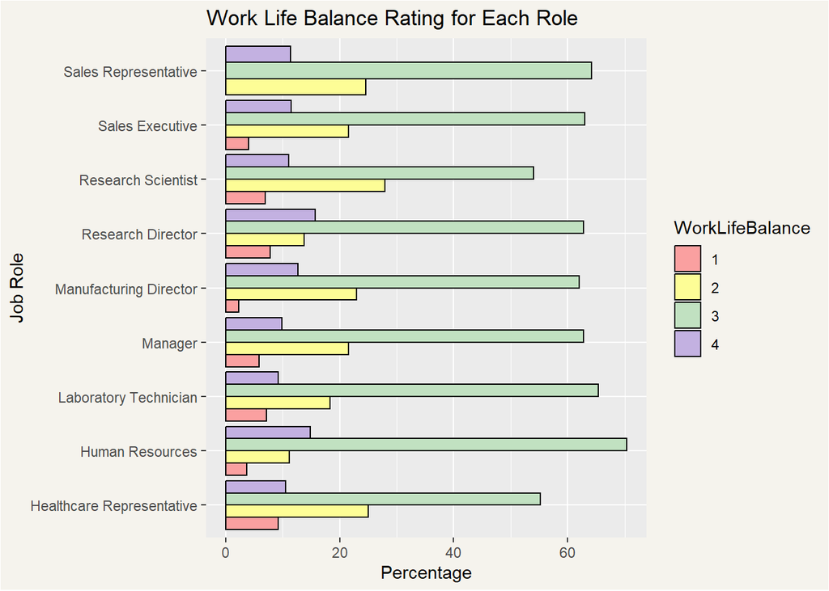

```r
percentagebalance = data.frame(jobrolesbalance,percentjobrolebalance)

color = c("#FAA0A0", "#FDFD96","#C1E1C1", "#C3B1E1", "#F8C8DC")

ggplot(percentagebalance, aes(x=JobRole, y = percent, fill = WorkLifeBalance)) +
  geom_bar(stat = "identity" , position = "dodge",color = "black") +
  ggtitle("Work Life Balance Rating for Each Role") +
  xlab("Job Role") +
  ylab("Percentage") +
  coord_flip() +
  theme(plot.background = element_rect("#f5f3ed"),
        legend.background = element_blank()) +
  scale_fill_manual(values = color)
```

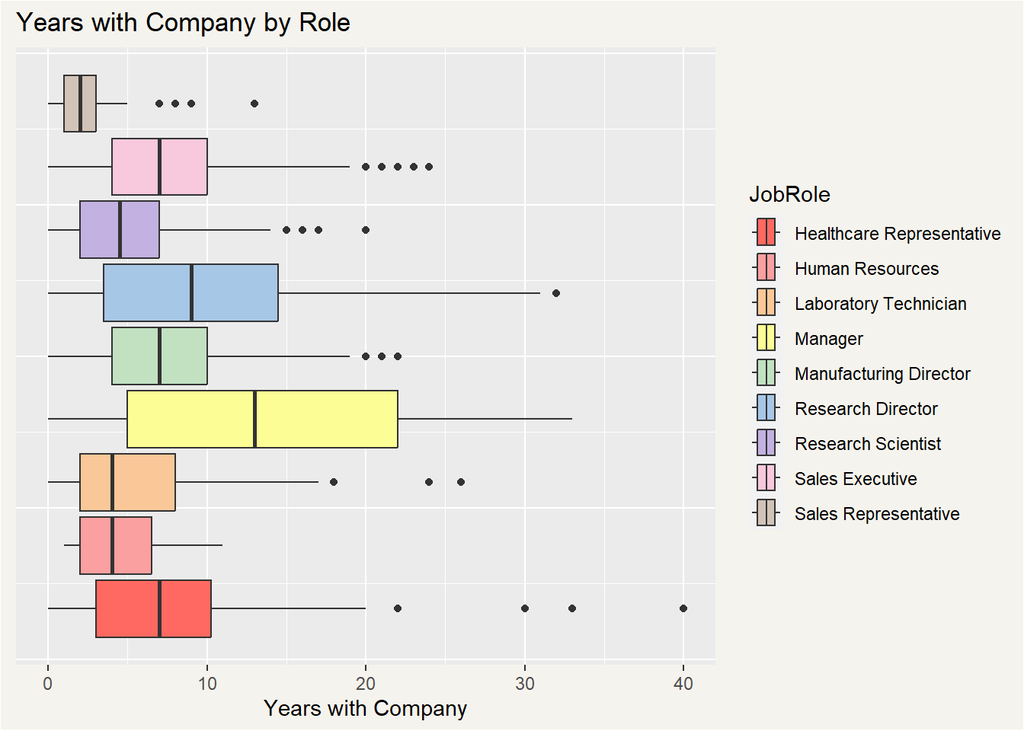

```r
# Years at company by Job Role
color = c("#FF6961","#FAA0A0", "#FAC898","#FDFD96","#C1E1C1", "#A7C7E7", "#C3B1E1", "#F8C8DC","#D1C3B7")
ggplot(data, aes(fill=JobRole, x = YearsAtCompany)) +
  geom_boxplot() +
  ggtitle("Years with Company by Role") +
  xlab("Years with Company") +
  theme(axis.text.y = element_blank(),
        axis.ticks.y = element_blank(),
        plot.background = element_rect("#f5f3ed"),
        legend.background = element_blank()) +
  scale_fill_manual(values = color)
```

```r
library(scales)
```

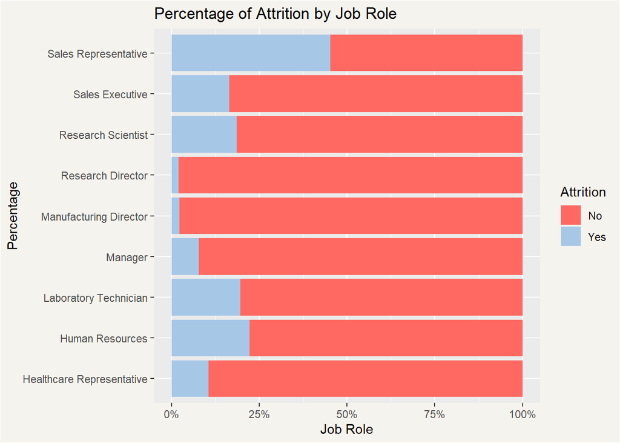

```r
color = c("#FF6961","#A7C7E7", "#C3B1E1", "#F8C8DC","#D1C3B7")
ggplot(data, aes(fill=Attrition, y = JobRole)) +
  geom_bar(position = "fill") +
  scale_x_continuous(labels = scales::percent) +
  ggtitle("Percentage of Attrition by Job Role") +
  xlab("Job Role") +
  ylab("Percentage")+
  scale_fill_manual(values = color) +
   theme(plot.background = element_rect("#f5f3ed"),
        legend.background = element_blank())
```

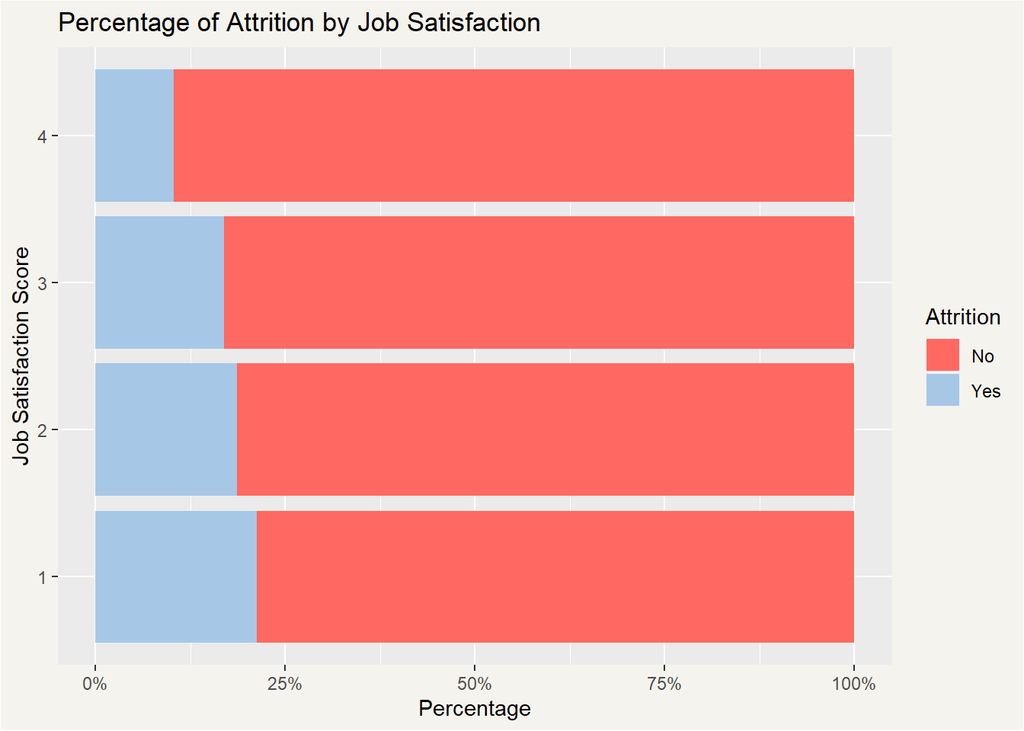

```r
ggplot(data, aes(fill=Attrition, y = JobSatisfaction)) +
  geom_bar(position = "fill") +
  scale_x_continuous(labels = scales::percent) +
  ggtitle("Percentage of Attrition by Job Satisfaction") +
  xlab("Percentage") +
  ylab("Job Satisfaction Score")+
  scale_fill_manual(values = color) +
   theme(plot.background = element_rect("#f5f3ed"),
        legend.background = element_blank())
```

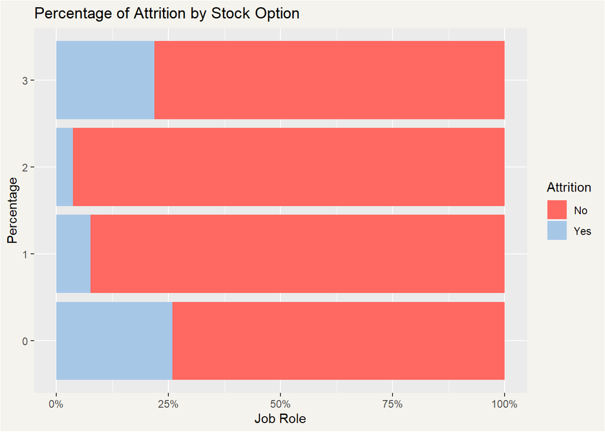

```r
ggplot(data, aes(fill=Attrition, y = StockOptionLevel)) +
  geom_bar(position = "fill") +
  scale_x_continuous(labels = scales::percent) +
  ggtitle("Percentage of Attrition by Stock Option") +
  xlab("Job Role") +
  ylab("Percentage")+
  scale_fill_manual(values = color) +
   theme(plot.background = element_rect("#f5f3ed"),
        legend.background = element_blank())
```